# The Districts of East and West Sussex

All twelve districts of the two counties side by side, through the national model behind *How to Pull the Right Lever*. **Draft for discussion.**

Author

Affiliation

Adam Dennett

Bartlett Centre for Advanced Spatial Analysis, University College London

Published

October 31, 2026

**WarningDraft for discussion**

This summary sits beneath the Sussex review and the East Sussex and West Sussex documents. Each district also has a document of its own, linked below. Every figure comes from published Department for Education data and the national models of [How to Pull the Right Lever](https://adamdennett.github.io/school_attainment_tool/pulling_the_right_lever_v2.html). Nothing uses pupil-level records.

# Summary

East and West Sussex have twelve districts between them, with 66 state-funded secondary schools. Brighton and Hove, a unitary authority, has no districts and is covered by the Lever report and the Sussex review.

- **Results range widely.** Mid Sussex (53rd of 264 districts in England) and Horsham (58th) are among the strongest in England; Hastings (263rd) and Crawley (235th) among the weakest.
- **Disadvantaged pupils are below England’s average in 11 of the twelve districts.** The widest gaps between them and other pupils are in Horsham, Mid Sussex and Lewes, all less disadvantaged than England.
- **Few district effects survive.** Crawley, Hastings, Lewes, Worthing and Eastbourne differ from the rest of their county on the published model. Once each school’s own record is counted, only Crawley still does. Almost everywhere, what looks like a district difference belongs to particular schools.
- **Absence fell in 7 of the twelve districts** between autumn and spring 2024/25 and 2025/26, and rose or held in Eastbourne, Lewes, Wealden, Horsham and Worthing. Over 2021/22 to 2024/25, the schools of Hastings ran more than a point above what their intakes predict.
- **Practice differs more than intake.** Suspensions run from 7.6 to 77.8 per 100 pupils (England 21.2), and reduced timetables from 0.11% to 0.75% of sessions (England 0.29%).

# 1 The tiers of this analysis

The Sussex documents are in three tiers:

- **Sussex**: the Sussex review, the region as one system.
- **The upper tier**: the three authorities that run schools. East Sussex, West Sussex, and Brighton and Hove, which is the subject of [How to Pull the Right Lever](https://adamdennett.github.io/school_attainment_tool/pulling_the_right_lever_v2.html).
- **The lower tier**: the districts of East and West Sussex, one document each, and this summary.
- **East Sussex:** Eastbourne, Hastings, Lewes, Rother and Wealden.
- **West Sussex:** Adur, Arun, Chichester, Crawley, Horsham, Mid Sussex and Worthing.

A district is not a local authority. Its schools take their county’s effect on the national models, and what is particular to a district shows up in its schools’ own residuals and in the district test (Section 4).

# 2 The districts side by side

Table 1: The twelve districts, 2024/25. Means of school-level figures. Ranks (1 = highest; for the gap, 1 = widest) are among the 264 districts in England with five or more schools; Hastings and Adur, with fewer, are each placed among them. Value added is the mean of each school’s over 2021/22 to 2024/25.

| District | County | Schools | FSM % | Att 8 | Att 8 disadv. | Gap | Value added | Schools below expectation |
| --- | --- | --- | --- | --- | --- | --- | --- | --- |
| Mid Sussex | West Sussex | 7 | 12.2 | 50.3 (53rd) | 35.5 (155th) | 16.9 (18th) | +0.9 | 2 of 7 |
| Horsham | West Sussex | 6 | 11.9 | 49.6 (58th) | 34.6 (188th) | 17.1 (16th) | +0.7 | 3 of 6 |
| Worthing | West Sussex | 6 | 17.6 | 49.0 (66th) | 35.8 (146th) | 15.9 (33rd) | +2.4 | 1 of 6 |
| Adur | West Sussex | 2 | 20.0 | 48.4 (80th) | 40.0 (72nd) | 10.6 (194th) | +1.4 | 1 of 2 |
| Rother | East Sussex | 5 | 25.6 | 45.4 (153rd) | 34.5 (193rd) | 14.6 (66th) | +0.1 | 3 of 5 |
| Lewes | East Sussex | 6 | 21.5 | 45.4 (155th) | 32.2 (234th) | 16.7 (21st) | +2.2 | 1 of 6 |
| Wealden | East Sussex | 6 | 20.0 | 45.1 (162nd) | 34.0 (199th) | 13.6 (101st) | +0.1 | 3 of 6 |
| Chichester | West Sussex | 6 | 17.8 | 43.6 (208th) | 31.0 (252nd) | 15.0 (56th) | -0.9 | 5 of 6 |
| Arun | West Sussex | 6 | 18.6 | 43.1 (215th) | 31.2 (248th) | 14.6 (70th) | -0.7 | 3 of 6 |
| Eastbourne | East Sussex | 6 | 30.0 | 42.7 (226th) | 33.2 (218th) | 13.9 (91st) | -0.4 | 4 of 6 |
| Crawley | West Sussex | 7 | 23.4 | 42.1 (235th) | 30.7 (255th) | 14.6 (69th) | -3.1 | 7 of 7 |
| Hastings | East Sussex | 3 | 35.1 | 37.8 (263rd) | 29.5 (262nd) | 13.0 (119th) | -3.6 | 3 of 3 |

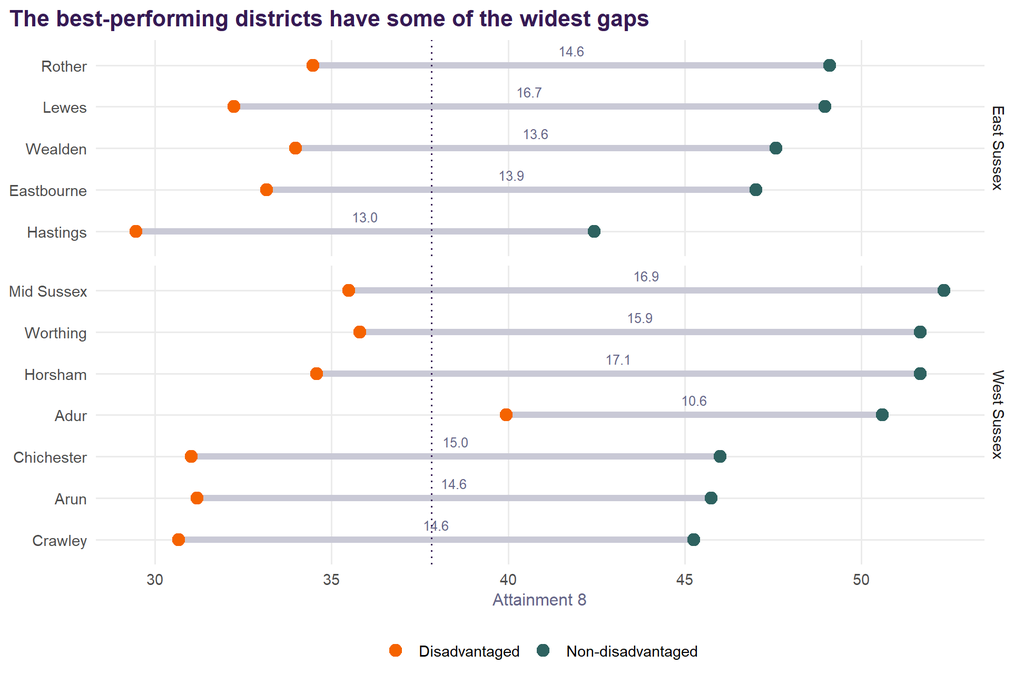

Figure 1: Attainment 8 for disadvantaged and non-disadvantaged pupils in each district, 2024/25, school means, with the gap between them. The dotted line is England’s average for disadvantaged pupils.

# 3 What explains each district’s results

Each district’s gap to England, split into the national model’s pieces as in its own document. The pieces sum to the district’s total. “Place” is the South East’s effect plus its county’s; “schools” is what the district’s own schools add beyond everything the model accounts for.

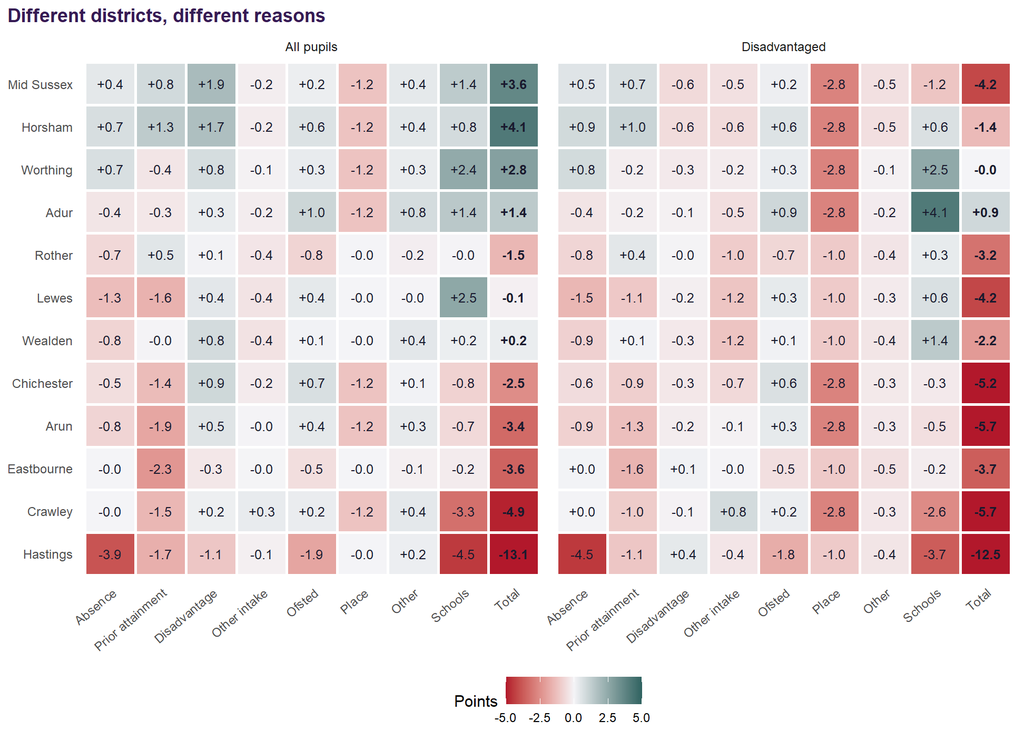

Figure 2: Why each district’s average Attainment 8 differs from England’s, all school-years 2021/22 to 2024/25, in approximate Attainment 8 points. Red pulls a district below England; teal lifts it above.

Three things stand out:

- **Absence** costs most in Hastings and Lewes (-3.9 and -1.3 points for all pupils), and lifts Horsham and Worthing.
- **Prior attainment** costs most in Eastbourne and Arun.
- **The districts’ own schools** add most for all pupils in Lewes and Worthing, and take most in Hastings and Crawley. For disadvantaged pupils they take most in Hastings and Crawley.

# 4 Is there a district effect?

The district test adds a district level to the national model (see the East Sussex document), with and without each school’s own record. An effect that disappears once schools are counted belongs to particular schools; one that survives is something the district’s schools share.

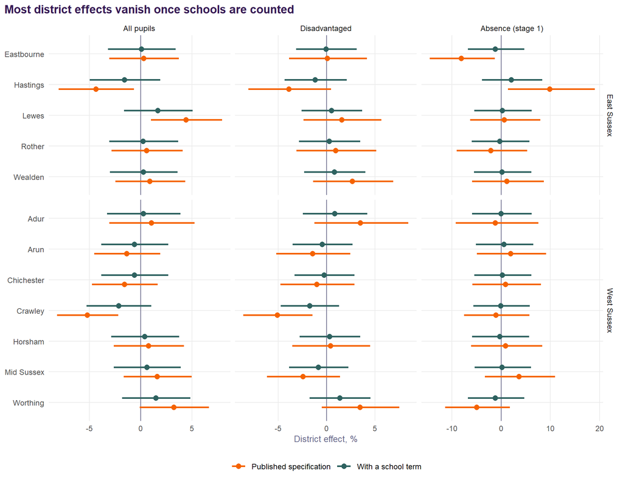

Figure 3: District effects over and above each county’s, with 95% intervals, on the published specification and with a school term.

- **Eastbourne:** absence (-8.2%) on the published model; none survives a school term.
- **Hastings:** all pupils (-4.4%), non-disadvantaged pupils (-3.9%) and absence (+9.9%) on the published model; none survives a school term.
- **Lewes:** all pupils (+4.4%) and non-disadvantaged pupils (+4.6%) on the published model; none survives a school term.
- **Crawley:** all pupils (-5.2%), disadvantaged pupils (-5.1%) and non-disadvantaged pupils (-5.8%) on the published model; with a school term, non-disadvantaged pupils (-3.5%) remains.
- **Worthing:** non-disadvantaged pupils (+3.2%) on the published model; none survives a school term.

Every other district has no effect distinguishable from zero on either specification.

# 5 Absence and practice

Table 2: Absence and practice by district. Overall absence, autumn and spring 2024/25 and 2025/26; absence above or below what the schools’ intakes predict, mean 2021/22 to 2024/25; illness and reduced timetables as a percentage of sessions, 2025/26; suspensions per 100 pupils, 2024/25.

| District | County | Absence 2024/25 | Absence 2025/26 | Above intake | Illness | Reduced timetable | Suspensions per 100 |
| --- | --- | --- | --- | --- | --- | --- | --- |
| Lewes | East Sussex | 9.7 | 10.1 | +0.2 | 5.14 | 0.30 | 18.7 |
| Wealden | East Sussex | 9.3 | 9.4 | +0.3 | 4.58 | 0.56 | 21.9 |
| Eastbourne | East Sussex | 8.7 | 8.8 | -0.4 | 3.97 | 0.45 | 24.9 |
| Rother | East Sussex | 8.4 | 8.0 | +0.1 | 3.73 | 0.34 | 17.1 |
| Hastings | East Sussex | 10.0 | 7.0 | +2.8 | 3.59 | 0.11 | 77.8 |
| Arun | West Sussex | 9.1 | 8.7 | +0.3 | 4.66 | 0.27 | 19.3 |
| Crawley | West Sussex | 8.8 | 8.3 | +0.0 | 3.81 | 0.60 | 18.5 |
| Worthing | West Sussex | 8.1 | 8.1 | -0.6 | 4.07 | 0.72 | 18.4 |
| Horsham | West Sussex | 7.6 | 8.1 | +0.1 | 4.29 | 0.75 | 13.6 |
| Chichester | West Sussex | 8.4 | 8.0 | +0.1 | 3.95 | 0.45 | 19.8 |
| Adur | West Sussex | 7.9 | 7.8 | -0.3 | 3.76 | 0.38 | 7.6 |
| Mid Sussex | West Sussex | 8.1 | 7.7 | +0.4 | 3.88 | 0.54 | 12.5 |
| England |  | 8.1 | 8.0 |  | 3.67 | 0.29 | 21.2 |

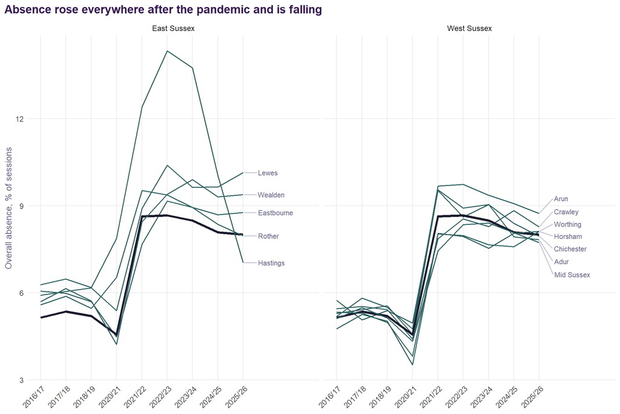

Figure 4: Overall absence, autumn and spring terms, 2016/17 to 2025/26, by district, with the county and England. Sessions-weighted; 2019/20 not collected.

# 6 District by district

Two or three lines on each district, from its own document.

## 6.1 East Sussex

**Eastbourne** (6 schools). Attainment 8 42.7, 226th of 264 districts; disadvantaged pupils 33.2 (218th) on 30% disadvantage. Its schools take 0.2 points for all pupils and take 0.2 points for disadvantaged pupils beyond what the model expects. Absence 8.8% in 2025/26, below what the intake predicts over 2021/22 to 2024/25 by 0.4 points; suspensions 24.9 per 100. A district effect on the published model disappears once each school’s record is counted. Read the Eastbourne document.

**Hastings** (3 schools). Attainment 8 37.8, 263rd of 265 districts; disadvantaged pupils 29.5 (262nd) on 35% disadvantage. Its schools take 4.5 points for all pupils and take 3.7 points for disadvantaged pupils beyond what the model expects. Absence 7.0% in 2025/26, above what the intake predicts over 2021/22 to 2024/25 by 2.8 points; suspensions 77.8 per 100. A district effect on the published model disappears once each school’s record is counted. Read the Hastings document.

**Lewes** (6 schools). Attainment 8 45.4, 155th of 264 districts; disadvantaged pupils 32.2 (234th) on 21% disadvantage. Its schools add 2.5 points for all pupils and add 0.6 points for disadvantaged pupils beyond what the model expects. Absence 10.1% in 2025/26, above what the intake predicts over 2021/22 to 2024/25 by 0.2 points; suspensions 18.7 per 100. A district effect on the published model disappears once each school’s record is counted. Read the Lewes document.

**Rother** (5 schools). Attainment 8 45.4, 153rd of 264 districts; disadvantaged pupils 34.5 (193rd) on 26% disadvantage. Its schools do about what is expected for all pupils and add 0.3 points for disadvantaged pupils beyond what the model expects. Absence 8.0% in 2025/26, above what the intake predicts over 2021/22 to 2024/25 by 0.1 points; suspensions 17.1 per 100. No district effect. Read the Rother document.

**Wealden** (6 schools). Attainment 8 45.1, 162nd of 264 districts; disadvantaged pupils 34.0 (199th) on 20% disadvantage. Its schools add 0.2 points for all pupils and add 1.4 points for disadvantaged pupils beyond what the model expects. Absence 9.4% in 2025/26, above what the intake predicts over 2021/22 to 2024/25 by 0.3 points; suspensions 21.9 per 100. No district effect. Read the Wealden document.

## 6.2 West Sussex

**Adur** (2 schools). Attainment 8 48.4, 80th of 265 districts; disadvantaged pupils 40.0 (72nd) on 20% disadvantage. Its schools add 1.4 points for all pupils and add 4.1 points for disadvantaged pupils beyond what the model expects. Absence 7.8% in 2025/26, below what the intake predicts over 2021/22 to 2024/25 by 0.3 points; suspensions 7.6 per 100. No district effect. Read the Adur document.

**Arun** (6 schools). Attainment 8 43.1, 215th of 264 districts; disadvantaged pupils 31.2 (248th) on 19% disadvantage. Its schools take 0.7 points for all pupils and take 0.5 points for disadvantaged pupils beyond what the model expects. Absence 8.7% in 2025/26, above what the intake predicts over 2021/22 to 2024/25 by 0.3 points; suspensions 19.3 per 100. No district effect. Read the Arun document.

**Chichester** (6 schools). Attainment 8 43.6, 208th of 264 districts; disadvantaged pupils 31.0 (252nd) on 18% disadvantage. Its schools take 0.8 points for all pupils and take 0.3 points for disadvantaged pupils beyond what the model expects. Absence 8.0% in 2025/26, above what the intake predicts over 2021/22 to 2024/25 by 0.1 points; suspensions 19.8 per 100. No district effect. Read the Chichester document.

**Crawley** (7 schools). Attainment 8 42.1, 235th of 264 districts; disadvantaged pupils 30.7 (255th) on 23% disadvantage. Its schools take 3.3 points for all pupils and take 2.6 points for disadvantaged pupils beyond what the model expects. Absence 8.3% in 2025/26, in line with what the intake predicts over 2021/22 to 2024/25; suspensions 18.5 per 100. A district effect survives each school’s own record for non-disadvantaged pupils (-3.5%). Read the Crawley document.

**Horsham** (6 schools). Attainment 8 49.6, 58th of 264 districts; disadvantaged pupils 34.6 (188th) on 12% disadvantage. Its schools add 0.8 points for all pupils and add 0.6 points for disadvantaged pupils beyond what the model expects. Absence 8.1% in 2025/26, above what the intake predicts over 2021/22 to 2024/25 by 0.1 points; suspensions 13.6 per 100. No district effect. Read the Horsham document.

**Mid Sussex** (7 schools). Attainment 8 50.3, 53rd of 264 districts; disadvantaged pupils 35.5 (155th) on 12% disadvantage. Its schools add 1.4 points for all pupils and take 1.2 points for disadvantaged pupils beyond what the model expects. Absence 7.7% in 2025/26, above what the intake predicts over 2021/22 to 2024/25 by 0.4 points; suspensions 12.5 per 100. No district effect. Read the Mid Sussex document.

**Worthing** (6 schools). Attainment 8 49.0, 66th of 264 districts; disadvantaged pupils 35.8 (146th) on 18% disadvantage. Its schools add 2.4 points for all pupils and add 2.5 points for disadvantaged pupils beyond what the model expects. Absence 8.1% in 2025/26, below what the intake predicts over 2021/22 to 2024/25 by 0.6 points; suspensions 18.4 per 100. A district effect on the published model disappears once each school’s record is counted. Read the Worthing document.

# Notes on method

Methods and sources are those of the East Sussex document. District membership comes from each school’s postcode (ONS postcode directory, via postcodes.io). Each district’s figures are read from its own data file (`data/area_<district>.rds`), built by `R/17_area_analysis.R`; the district effects come from `R/18_district_effects.R`. This summary is `sussex_districts.qmd`, rendered by `R/20_district_reports.R` with the district documents. The format of every tier is described in `AREA_REPORTS.md`.